# Car Sales and Macro-Economics

Christophe Duong

12/21/2014

# 1 Data Source and Description

Two datasets were extracted manually from knoema.com:

World Motor Vehicle Sales by country and type 2005-2012 (Publication date: 25 February, 2013): http://knoema.com/lnubnsd/world-motor-vehicle-sales-by-country-and-type-2005-2012

The World Economic Outlook (WEO) database contains selected macroeconomic data series from the statistical appendix of the World Economic Outlook report, which presents the IMF staff’s analysis and projections of economic developments at the global level, in major country groups and in many individual countries: (Publication date: 07 October, 2014) http://knoema.com/IMFWEO2014Oct/imf-world-economic-outlook-october-2014

After retrieving them, these datasets were merged and combined into a single csv file that we are now using in the following analysis using R where we try to build a Linear Regression model using OLS to predict Car Sales figures depending on macroeconomics measures of any country in the world.

# 2 Basic Analysis

## 2.1 Data loading and preparation

Load the data, shorten the column names to get cleaner output and remove outliers from all country (named under ‘world’):

```r
df <- read.csv('data.csv')

names(df)[names(df) == 'Gross.domestic.product..current.prices..U.S..dollars.'] <- 'GDP.USD'
names(df)[names(df) == 'Current.account.balance..Percent.of.GDP.'] <- 'Current.Acc.Bal.PercGDP'
names(df)[names(df) == 'Current.account.balance..U.S..dollars.'] <- 'Current.Acc.Bal.USD'
names(df)[names(df) == 'Employment..Persons.'] <- 'Employment'
names(df)[names(df) == 'Export.volume.of.goods.and.services..Percent.change.'] <- 'Export'
names(df)[names(df) == 'Gross.domestic.product.based.on.purchasing.power.parity..PPP..valuation.of.country.GDP..Current.international.dollar.'] <- 'GDP.PPP'
names(df)[names(df) == 'Gross.domestic.product.per.capita..current.prices..U.S..dollars.'] <- 'GDP.per.capita'
names(df)[names(df) == 'Gross.domestic.product..constant.prices..Percent.change.'] <- 'GDP.PercChange'
names(df)[names(df) == 'Gross.domestic.product..deflator..Index.'] <- 'GDP.deflatorIndex'
names(df)[names(df) == 'Gross.national.savings..Percent.of.GDP.'] <- 'National.Savings'
names(df)[names(df) == 'Import.volume.of.goods.and.services..Percent.change.'] <- 'Import'
names(df)[names(df) == 'Inflation..average.consumer.prices..Index.'] <- 'Inflation.Index'
names(df)[names(df) == 'Inflation..average.consumer.prices..Percent.change.'] <- 'Inflation.PercChange'
names(df)[names(df) == 'Investment..Percent.of.GDP.'] <- 'Investment'
names(df)[names(df) == 'Output.gap.in.percent.of.potential.GDP..Percent.of.potential.GDP.'] <- 'Output.Gap'
names(df)[names(df) == 'Population..Persons.'] <- 'Population'
names(df)[names(df) == 'Trade.volume.of.goods.and.services..Percent.change.'] <- 'Trade.Volume'
names(df)[names(df) == 'Unemployment.rate..Percent.of.total.labor.force.'] <- 'Unemployment.Rate'

df <- df[df$GDP.USD < 40000,]
todrop <- c("Commercial.vehicles","Passengers.Cars", "Trade.Volume")
df <- df[,!(names(df) %in% todrop)]
```

## 2.2 Basic Scatter Plot

We want to check if some macroeconomics metrics would be linearly dependent with car sales in the world. Let’s first look at a scatter plot:

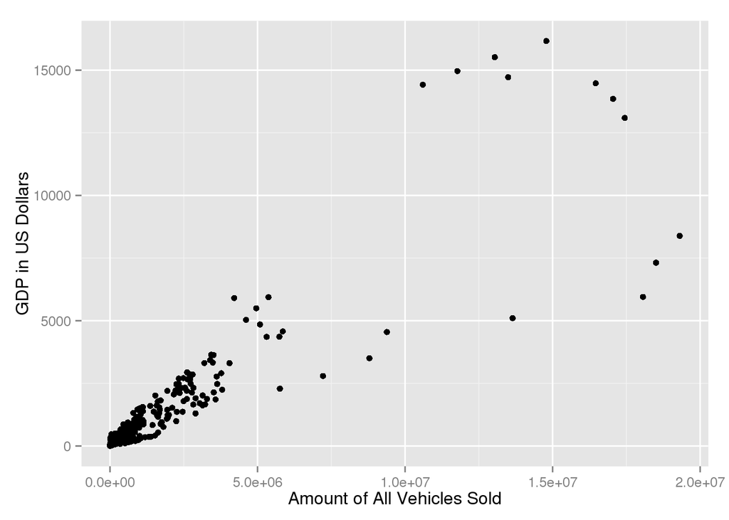

```r
library(ggplot2)
qplot(df$All.vehicles, df$GDP.USD) +
  xlab("Amount of All Vehicles Sold") +
  ylab("GDP in US Dollars")
```

## 2.3 Fit a Simple Linear Regression Model

Let’s fit a linear regression model through that data and look at the resulting residuals.

As we are using only one independent variable, it is called a **simple linear regression**:

```r
excludedCountries <- c('japan', 'china', 'united states of america');
dfExcluded <- df[!(df$country %in% excludedCountries),]
dfNonExcluded <- df[(df$country %in% excludedCountries),]
fit <- lm(data=dfExcluded, All.vehicles ~ GDP.USD)
summary(fit)
```

```
##
## Call:
## lm(formula = All.vehicles ~ GDP.USD, data = dfExcluded)
##
## Residuals:
##     Min      1Q  Median      3Q     Max
## -739231  -43604    -778   10171 1479081
##
## Coefficients:
##             Estimate Std. Error t value Pr(>|t|)
## (Intercept) -9640.85    7644.06  -1.261    0.208
## GDP.USD      1133.73      12.62  89.804   <2e-16 ***
## ---
## Signif. codes:  0 '***' 0.001 '**' 0.01 '*' 0.05 '.' 0.1 ' ' 1
##
## Residual standard error: 220400 on 1030 degrees of freedom
## Multiple R-squared:  0.8867, Adjusted R-squared:  0.8866
## F-statistic:  8065 on 1 and 1030 DF,  p-value: < 2.2e-16
```

```r
yhat <- predict(fit)
yhat2 <- predict(fit, newdata = dfNonExcluded)
```

We actually identified visually a certain number of countries such as Japan, China and USA to behave quite differently from the other countries of the world as their car sales are not as linearly dependent as the others. Therefore, we choose to display the residual bars in green for all the countries other than these ‘outlier’ countries which are displayed in red:

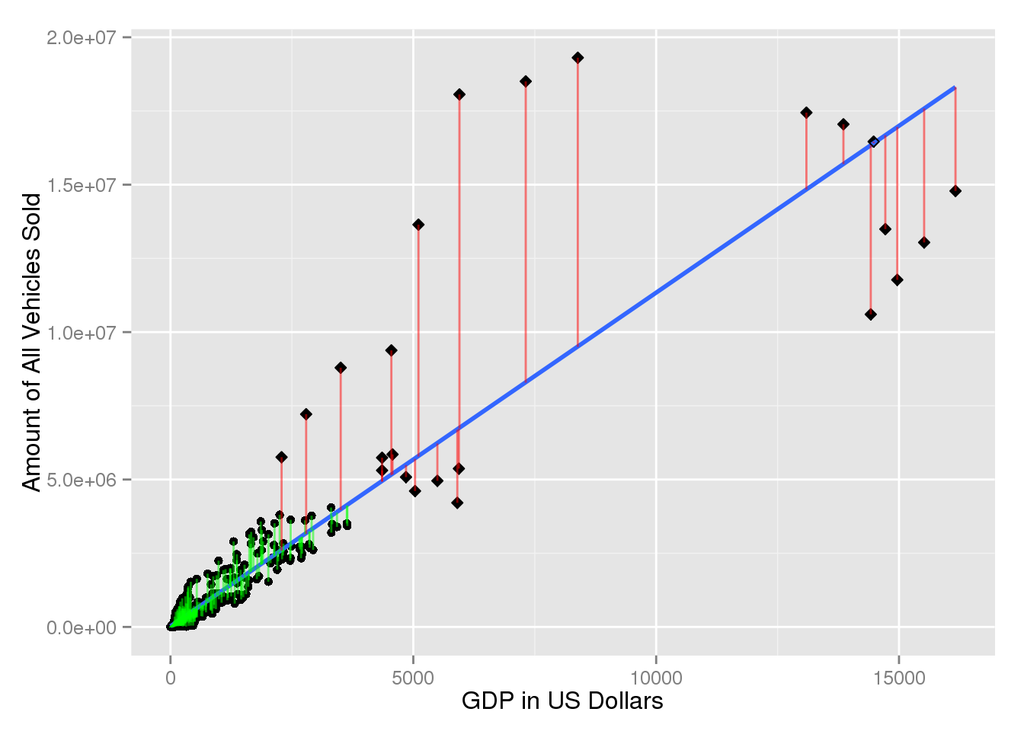

```r
qplot(x = GDP.USD, y = All.vehicles, data=df) +
      geom_smooth(method="lm", se=FALSE, size=1, data=df) +
      geom_segment(data= dfExcluded, x=dfExcluded$GDP.USD,
                   y=dfExcluded$All.vehicles,
                   xend=dfExcluded$GDP.USD,
                   yend=yhat, colour=I("green"),alpha=0.5) +
      geom_point(data=dfNonExcluded, shape=23) +
      geom_segment(data= dfNonExcluded, x=dfNonExcluded$GDP.USD,
                   y=dfNonExcluded$All.vehicles,
                   xend=dfNonExcluded$GDP.USD,
                   yend=yhat2, colour=I("red"),alpha=0.5) +
      ylab("Amount of All Vehicles Sold") +
      xlab("GDP in US Dollars")
```

Using some various built-in regression diagnostics plots:

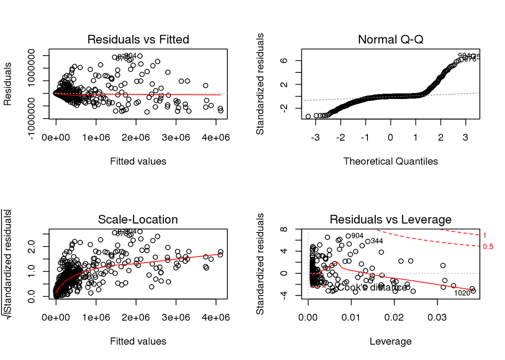

```r
par(mfrow=c(2,2))
plot(fit)
```

We can already notice that some of the assumptions on this model based on linear regression are not respected (normality for example)

# 3 Data Analysis using more variables

## 3.1 Fit a Multiple Linear Regression Model

Now, let’s consider all the independent variables together, therefore we are running a *multiple linear regression* instead:

```r
fitMore <- lm(data=df, All.vehicles ~ . - year - X - country)
summary(fitMore)
```

```
##
## Call:
## lm(formula = All.vehicles ~ . - year - X - country, data = df)
##
## Residuals:
##      Min       1Q   Median       3Q      Max
## -2231848  -165246   -14508   128200  1861277
##
## Coefficients:
##                           Estimate Std. Error t value Pr(>|t|)
## (Intercept)              7.755e+05  4.828e+05   1.606  0.10988
## Current.Acc.Bal.PercGDP -3.512e+05  1.194e+05  -2.942  0.00367 **
## Current.Acc.Bal.USD     -3.959e+03  4.603e+02  -8.601 2.92e-15 ***
## Employment               1.449e+05  1.900e+04   7.624 1.14e-12 ***
## Export                  -1.030e+04  8.223e+03  -1.253  0.21188
## GDP.PPP                  2.463e+02  2.013e+02   1.223  0.22275
## GDP.per.capita          -4.718e+00  2.268e+00  -2.080  0.03886 *
## GDP.PercChange           1.117e+03  1.682e+04   0.066  0.94712
## GDP.USD                 -3.894e+02  1.895e+02  -2.055  0.04124 *
## GDP.deflatorIndex        4.590e+03  3.111e+03   1.475  0.14183
## National.Savings         3.818e+05  1.193e+05   3.199  0.00161 **
## Import                   1.271e+04  7.820e+03   1.625  0.10576
## Inflation.Index         -7.296e+03  4.673e+03  -1.561  0.12014
## Inflation.PercChange     1.967e+04  2.641e+04   0.745  0.45727
## Investment              -3.942e+05  1.191e+05  -3.311  0.00111 **
## Output.Gap               2.422e+04  1.317e+04   1.840  0.06740 .
## Population              -1.790e+04  1.089e+04  -1.643  0.10200
## Unemployment.Rate       -8.717e+03  1.197e+04  -0.728  0.46748
## ---
## Signif. codes:  0 '***' 0.001 '**' 0.01 '*' 0.05 '.' 0.1 ' ' 1
##
## Residual standard error: 402000 on 190 degrees of freedom
##   (848 observations deleted due to missingness)
## Multiple R-squared:  0.9826, Adjusted R-squared:  0.9811
## F-statistic: 632.5 on 17 and 190 DF,  p-value: < 2.2e-16
```

## 3.2 Stepwise Linear Regression Model

The previous model was ending up using a lot of independent variables that are not significant. Let’s optimize the model by trying to add or remove some of them and optimize by looking at the Akaike information criterion (AIC) value which tries to deal with the concepts of goodness of fit of the model and its complexity:

```r
library(MASS)
fitStep <- stepAIC(fitMore, direction="both", trace=0)

summary(fitStep)
```

```
##
## Call:
## lm(formula = All.vehicles ~ Current.Acc.Bal.PercGDP + Current.Acc.Bal.USD +
##     Employment + GDP.per.capita + GDP.USD + National.Savings +
##     Import + Investment + Output.Gap + Unemployment.Rate, data = df)
##
## Residuals:
##      Min       1Q   Median       3Q      Max
## -2336174  -150819   -15313   142328  1862236
##
## Coefficients:
##                           Estimate Std. Error t value Pr(>|t|)
## (Intercept)              5.283e+05  2.445e+05   2.161 0.031919 *
## Current.Acc.Bal.PercGDP -3.818e+05  1.156e+05  -3.302 0.001139 **
## Current.Acc.Bal.USD     -3.937e+03  3.659e+02 -10.760  < 2e-16 ***
## Employment               1.185e+05  7.956e+03  14.891  < 2e-16 ***
## GDP.per.capita          -4.534e+00  2.154e+00  -2.105 0.036587 *
## GDP.USD                 -3.165e+02  8.454e+01  -3.744 0.000238 ***
## National.Savings         4.116e+05  1.156e+05   3.562 0.000461 ***
## Import                   5.422e+03  3.401e+03   1.594 0.112520
## Investment              -4.206e+05  1.154e+05  -3.646 0.000341 ***
## Output.Gap               2.292e+04  1.146e+04   2.000 0.046885 *
## Unemployment.Rate       -2.345e+04  9.434e+03  -2.486 0.013761 *
## ---
## Signif. codes:  0 '***' 0.001 '**' 0.01 '*' 0.05 '.' 0.1 ' ' 1
##
## Residual standard error: 400300 on 197 degrees of freedom
##   (848 observations deleted due to missingness)
## Multiple R-squared:  0.9821, Adjusted R-squared:  0.9812
## F-statistic:  1084 on 10 and 197 DF,  p-value: < 2.2e-16
```

We can now notice that the R-Squared and model’s overal p-value has been barely affected but we went from a F-Statistic of 632.5 to 1084 with the stepwise approach.

As a test, let’s try to remove even some more of the non-significant variables and see the effect on the R-Squared value:

```r
fitStep <- lm(data=df, All.vehicles ~ Current.Acc.Bal.PercGDP + Current.Acc.Bal.USD + Employment + GDP.USD + National.Savings + Investment + Output.Gap)

summary(fitStep)
```

```
##
## Call:
## lm(formula = All.vehicles ~ Current.Acc.Bal.PercGDP + Current.Acc.Bal.USD +
##     Employment + GDP.USD + National.Savings + Investment + Output.Gap,
##     data = df)
##
## Residuals:
##      Min       1Q   Median       3Q      Max
## -2447926  -134192   -10383   140473  1921686
##
## Coefficients:
##                          Estimate Std. Error t value Pr(>|t|)
## (Intercept)               39031.6   194165.8   0.201 0.840886
## Current.Acc.Bal.PercGDP -364888.7   116672.4  -3.127 0.002026 **
## Current.Acc.Bal.USD       -3703.1      362.8 -10.207  < 2e-16 ***
## Employment               120797.7     7913.9  15.264  < 2e-16 ***
## GDP.USD                    -329.4       84.4  -3.903 0.000130 ***
## National.Savings         390335.5   116310.6   3.356 0.000946 ***
## Investment              -393690.3   115914.1  -3.396 0.000824 ***
## Output.Gap                34058.5    10625.2   3.205 0.001570 **
## ---
## Signif. codes:  0 '***' 0.001 '**' 0.01 '*' 0.05 '.' 0.1 ' ' 1
##
## Residual standard error: 408300 on 200 degrees of freedom
##   (848 observations deleted due to missingness)
## Multiple R-squared:  0.9811, Adjusted R-squared:  0.9805
## F-statistic:  1487 on 7 and 200 DF,  p-value: < 2.2e-16
```

The Adjusted R-Squared is now slightly decreasing from 0.9812 to 0.9805 but the F-Statistic is again increasing from 1084 to 1487.

## 3.3 Eliminating correlation and looking at interactions

```r
fitInteraction <- lm(data=df, All.vehicles ~  GDP.USD*Investment + Output.Gap)
summary(fitInteraction)
```

```
##
## Call:
## lm(formula = All.vehicles ~ GDP.USD * Investment + Output.Gap,
##     data = df)
##
## Residuals:
##      Min       1Q   Median       3Q      Max
## -1416561  -199882   -30574   151027  1952661
##
## Coefficients:
##                      Estimate Std. Error t value Pr(>|t|)
## (Intercept)         1.155e+06  1.978e+05   5.839 2.06e-08 ***
## GDP.USD            -4.345e+02  8.372e+01  -5.190 5.08e-07 ***
## Investment         -5.554e+04  8.958e+03  -6.200 3.10e-09 ***
## Output.Gap          4.841e+04  1.026e+04   4.719 4.40e-06 ***
## GDP.USD:Investment  6.997e+01  4.089e+00  17.113  < 2e-16 ***
## ---
## Signif. codes:  0 '***' 0.001 '**' 0.01 '*' 0.05 '.' 0.1 ' ' 1
##
## Residual standard error: 403900 on 203 degrees of freedom
##   (848 observations deleted due to missingness)
## Multiple R-squared:  0.9813, Adjusted R-squared:  0.9809
## F-statistic:  2659 on 4 and 203 DF,  p-value: < 2.2e-16
```

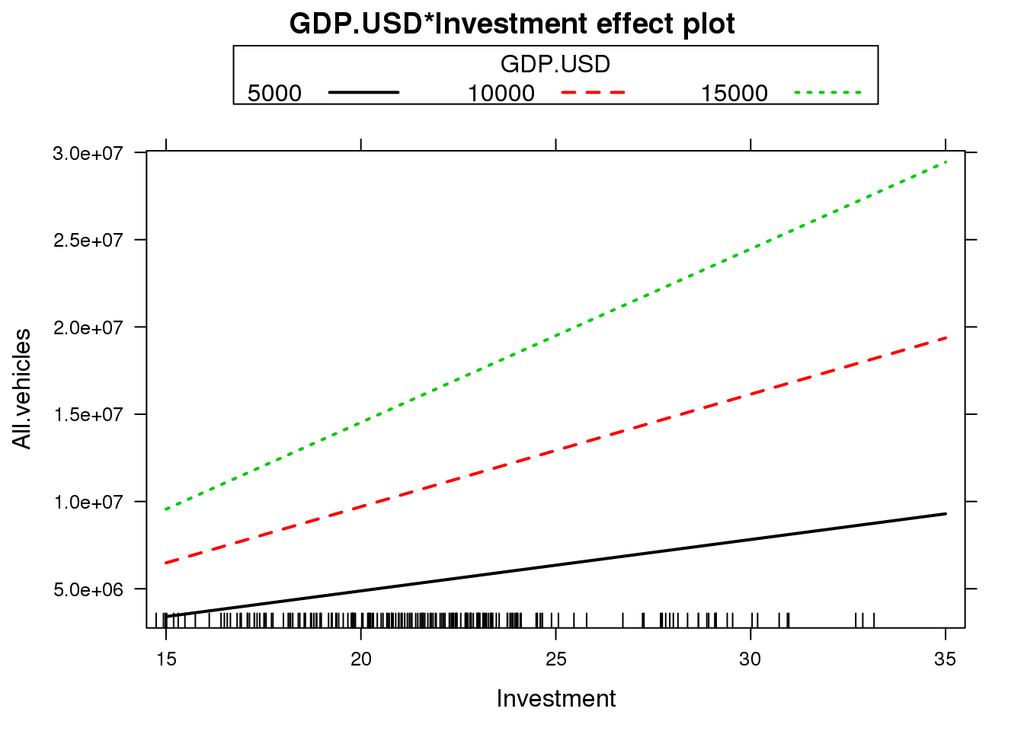

```r
library(effects)
plot(effect("GDP.USD:Investment", fitInteraction, xlevels=list(wt=c(2,3))), multiline=TRUE)
```

```r
fitStep <- fitInteraction
```

Again the R-Squared is not significantly affected but the F-Statistic gain a bigger amount of increase up to 2659. We can also conclude from the interaction graph that depending on the GDP level, when Investments made by the goverment are higher, there is also higher car sales in that country. This effect is more pronounced when the GDP is higher than when it is lower.

## 3.4 Regression Diagnostics

### 3.4.1 Checking Linear Relation

If the relation between the IVs and the DV is linear, *no pattern* should appear in the scatter plot:

```r
library(car)
```

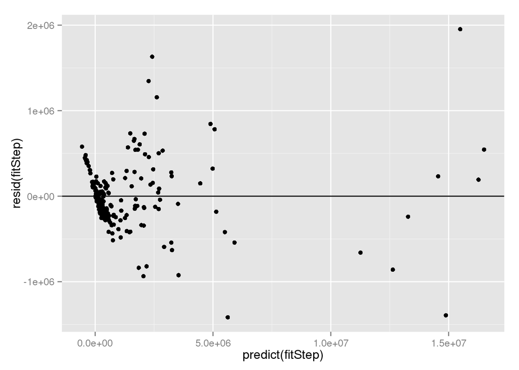

```r
qplot(predict(fitStep), resid(fitStep), geom="point") + geom_hline(yintercept=0)
```

As it seems to exist a slight pattern, the linear relation in this data set may not hold true.

### 3.4.2 Checking Normality

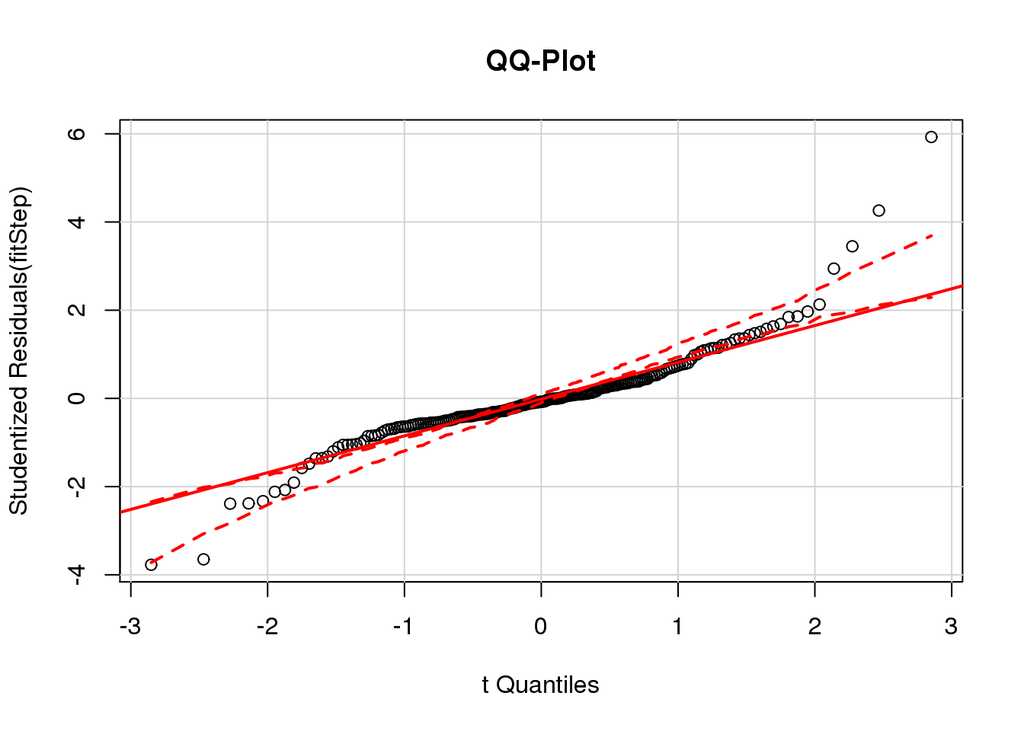

```r
x <- resid(fitStep)
qqPlot(fitStep,main = "QQ-Plot")
```

```
## stat_bin: binwidth defaulted to range/30. Use 'binwidth = x' to adjust this.
```

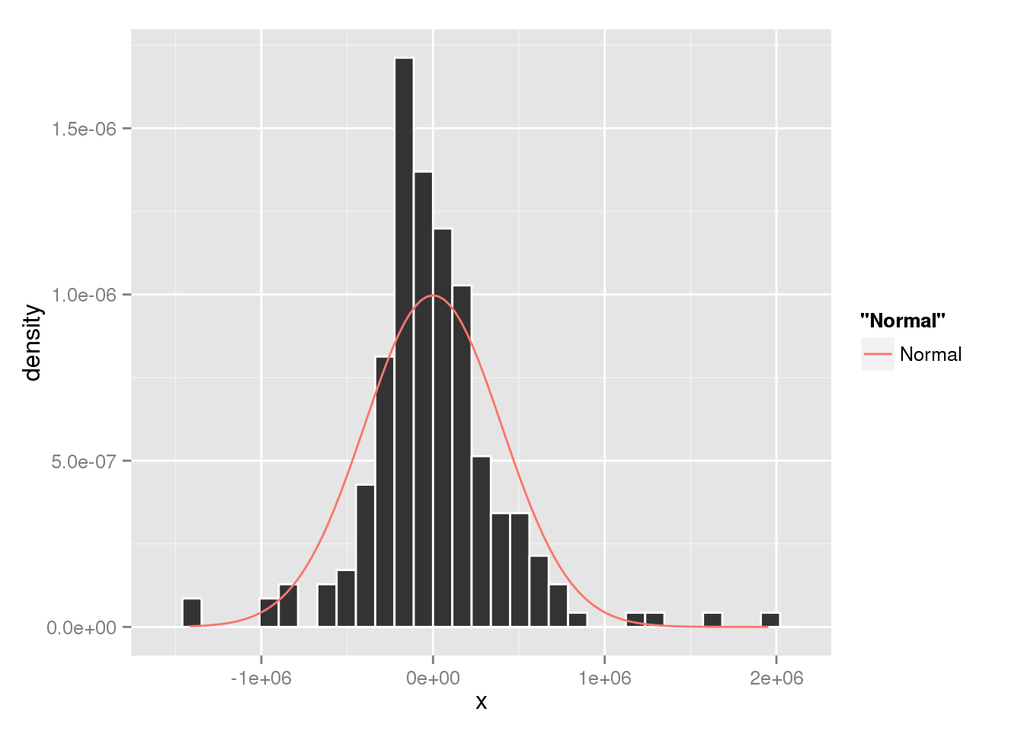

```r
qplot(x,geom="blank") +
geom_histogram( colour=I("white"), aes(y=..density..)) +
  stat_function(fun=dnorm, aes(colour="Normal"),arg=list(mean=mean(resid(fitStep)),
                                                         sd=sd(resid(fitStep))))
```

It almost look normal but because of some outliers as denoted previously in the scatter plot, normality may not be true either for all the countries.

### 3.4.3 Checking Homoscedasticity

```r
library(lmtest)
```

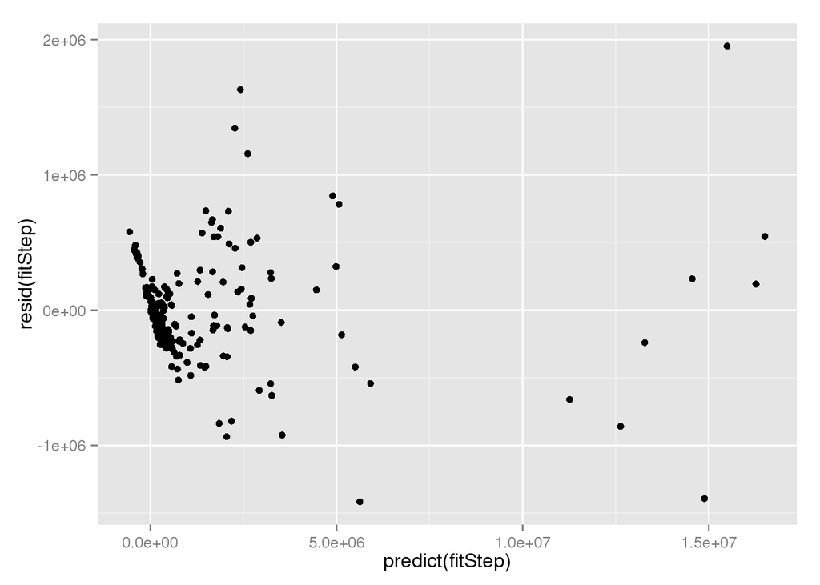

```r
qplot(predict(fitStep),resid(fitStep), geom="point")
```

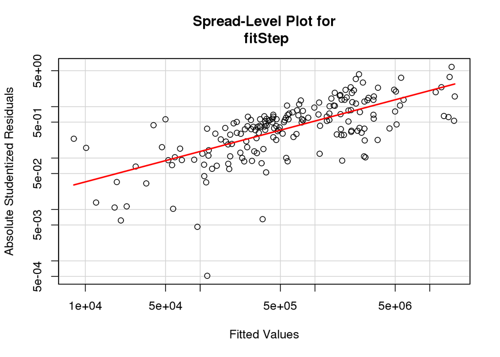

```
##
## Suggested power transformation:  0.4082004
```

```r
spreadLevelPlot(fitStep)
```

```r
bptest(fitStep)
```

```
##
##  studentized Breusch-Pagan test
##
## data:  fitStep
## BP = 48.7869, df = 4, p-value = 6.468e-10
```

The line doesn’t seem to be horizontal and the statistic test of Breusch–Pagan seems to indicate heteroskedasticity in our model with a significant p-value below our alpha threshold so we may not satisfy the homogeneity of variance assumption either.

### 3.4.4 Checking Independence

```r
durbinWatsonTest(fitStep)
```

```
##  lag Autocorrelation D-W Statistic p-value
##    1       0.4511046      1.070736       0
##  Alternative hypothesis: rho != 0
```

# 4 Conclusion

As a conclusion, even though we may have obtained an amazing Ordinary Least Square Linear Regression model with an adjusted R-Squared of 0.9809, we failed to verify multiple of its assumptions so the built model may not be usable to predict and plan marketing strategies of Car Sales per country based on macroeconomics measures.